# 29 Quarto 형식

### 29.5.2 Shiny

htmlwidgets는 **클라이언트 측(client-side)** 대화형 기능을 제공합니다 — 모든 상호 작용은 R과 독립적으로 브라우저에서 발생합니다. 한편으로는 R에 연결하지 않고도 HTML 파일을 배포할 수 있기 때문에 훌륭합니다. 그러나 이는 기본적으로 HTML과 JavaScript로 구현된 것들로만 할 수 있는 일을 제한합니다. 대안적인 접근 방식은 JavaScript가 아니라 R 코드를 사용하여 대화형 기능을 만들 수 있게 해주는 패키지인 **shiny**를 사용하는 것입니다.

Quarto 문서에서 Shiny 코드를 호출하려면 YAML 헤더에 `server: shiny`를 추가하세요:

```yaml
title: "Shiny Web App"
format: html
server: shiny
```

그런 다음 “input” 함수를 사용하여 문서에 대화형 구성 요소를 추가할 수 있습니다:

```r
library(shiny)

textInput("name", "What is your name?")
numericInput("age", "How old are you?", NA, min = 0, max = 150)
```

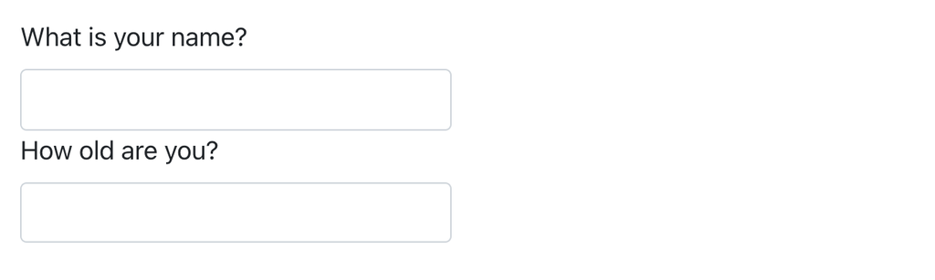

또한 Shiny 서버에서 실행해야 하는 코드가 포함된 청크 옵션 `context: server`가 있는 코드 청크도 필요합니다.

그런 다음 `input$name` 및 `input$age`로 값을 참조할 수 있으며, 이들을 사용하는 코드는 값이 변경될 때마다 자동으로 다시 실행됩니다.

Shiny 상호 작용은 **서버 측(server-side)** 에서 발생하기 때문에 여기에서 라이브 Shiny 앱을 보여드릴 수 없습니다. 즉, JavaScript를 모르고도 대화형 앱을 작성할 수 있지만, 이를 실행할 서버가 필요합니다. 이로 인해 물류적인 문제가 발생합니다: Shiny 앱을 온라인에서 실행하려면 Shiny 서버가 필요합니다. 자신의 컴퓨터에서 Shiny 앱을 실행할 때 Shiny는 자동으로 Shiny 서버를 설정해 주지만, 이러한 종류의 대화형 기능을 온라인에 게시하려면 공용 Shiny 서버가 필요합니다. 이것이 Shiny의 근본적인 트레이드오프입니다: R에서 할 수 있는 모든 것을 Shiny 문서에서 할 수 있지만, 누군가 R을 실행하고 있어야 합니다.

Shiny에 대해 더 배우고 싶다면 Hadley Wickham이 쓴 Mastering Shiny(https://mastering-shiny.org)를 읽어보시기를 권장합니다.

## 29.6 웹사이트와 책

약간의 추가 인프라를 사용하면 Quarto를 사용하여 완전한 웹사이트나 책을 생성할 수 있습니다:

- `.qmd` 파일을 단일 디렉토리에 넣습니다. `index.qmd`가 홈 페이지가 됩니다.
- 사이트 탐색을 제공하는 `_quarto.yml`이라는 이름의 YAML 파일을 추가합니다. 이 파일에서 `project` 유형을 `book` 또는 `website`로 설정합니다. 예:

  ```yaml
  project:
    type: book
  ```

예를 들어 다음 `_quarto.yml` 파일은 세 개의 소스 파일인 `index.qmd`(홈 페이지), `viridis-colors.qmd`, `terrain-colors.qmd`로부터 웹사이트를 만듭니다.

```
project:
  type: website

website:
  title: "A website on color scales"
  navbar:
    left:
      - href: index.qmd
        text: Home
      - href: viridis-colors.qmd
        text: Viridis colors
      - href: terrain-colors.qmd
        text: Terrain colors
```

책에 필요한 `_quarto.yml` 파일도 매우 비슷하게 구성됩니다. 다음 예제는 세 가지 다른 출력(`html`, `pdf`, `epub`)으로 렌더링되는 4개의 장으로 구성된 책을 만드는 방법을 보여줍니다. 다시 한번 말씀드리지만 소스 파일은 `.qmd` 파일입니다.

```
project:
  type: book

book:
  title: "A book on color scales"
  author: "Jane Coloriste"
  chapters:
    - index.qmd
    - intro.qmd
    - viridis-colors.qmd
    - terrain-colors.qmd

format:
  html:
    theme: cosmo
  pdf: default
  epub: default
```

웹사이트와 책에는 RStudio 프로젝트를 사용하는 것이 좋습니다. `_quarto.yml` 파일을 기반으로 RStudio는 작업 중인 프로젝트 유형을 인식하고, 웹사이트와 책을 렌더링하고 미리 보는 데 사용할 수 있는 Build 탭을 IDE에 추가합니다. 웹사이트와 책 모두 `quarto::quarto_render()`를 사용하여 렌더링할 수도 있습니다.

Quarto 웹사이트에 대해서는 https://quarto.org/docs/websites, 책에 대해서는 https://quarto.org/docs/books에서 자세히 읽어보세요.

## 29.7 기타 형식

Quarto는 더 많은 출력 형식을 제공합니다:

- Quarto Journal Templates를 사용하여 학술지 논문을 작성할 수 있습니다: https://quarto.org/docs/journals/templates.html.
- `format: ipynb`를 사용하여 Quarto 문서를 Jupyter Notebook으로 출력할 수 있습니다: https://quarto.org/docs/reference/formats/ipynb.html.

더 많은 형식 목록은 https://quarto.org/docs/output-formats/all-formats.html을 참조하세요.

## 29.8 요약

이 장에서는 정적 및 대화형 문서에서 프레젠테이션, 웹사이트 및 책에 이르기까지 Quarto로 결과를 전달하기 위한 다양한 옵션을 제시했습니다.

이러한 다양한 형식으로 효과적인 소통을 하는 방법에 대해 더 자세히 배우려면 다음 리소스를 추천합니다:

- 프레젠테이션 기술을 향상시키려면 Neal Ford, Matthew McCollough, Nathaniel Schutta가 쓴 [*Presentation Patterns*](https://presentationpatterns.com/)를 시도해 보세요. 프레젠테이션을 개선하기 위해 적용할 수 있는 효과적인 패턴(낮은 수준과 높은 수준 모두) 세트를 제공합니다.
- 학술 발표를 한다면 [*Leek group guide to giving talks*](https://github.com/jtleek/talkguide)가 마음에 드실 것입니다.
- 우리는 직접 들어보지는 못했지만, Matt McGarrity의 대중 연설 온라인 강의에 대해 좋은 이야기를 들었습니다: https://www.coursera.org/learn/public-speaking.
- 대시보드를 많이 만들고 있다면 Stephen Few의 [*Information Dashboard Design: The Effective Visual Communication of Data*](https://www.amazon.com/Information-Dashboard-Design-Effective-Communication/dp/0596100167)를 꼭 읽어보세요. 단지 예쁘기만 한 것이 아니라 정말로 유용한 대시보드를 만드는 데 도움이 될 것입니다.
- 아이디어를 효과적으로 전달하는 것은 종종 그래픽 디자인에 대한 약간의 지식으로부터 이득을 얻습니다. Robin Williams의 [*The Non-Designer’s Design Book*](https://www.amazon.com/Non-Designers-Design-Book-4th/dp/0133966151)은 시작하기에 훌륭한 장소입니다.